# Introduction to Text Mining

Eric Goh

2020 M10 4

Text Mining deals with the textual data. Data Mining usually deals with numerical data. The following is an introduction to text mining. To use Text Mining in R, we need to install RTextTools, tm, and SnowballC packages:

install.packages("tm");  
install.packages("Snowballc");

install.packages("rvest");  
install.packages("xml2");  
install.packages("stringr");  
install.packages("dplyr");  
install.packages("wordcloud");  
install.packages("RColorBrewer");  
install.packages("ggplot2");  
install.packages("caTools");  
install.packages("randomForest");  
install.packages("caret");

[figure not shown]

We include the plugins in our R scripts.

```r
library(rvest)
library(xml2)
library(stringr)
library(dplyr)
library(tm)
```

```r
library(SnowballC)
library(wordcloud)
library(RColorBrewer)
library(ggplot2)
library(caTools)
library(randomForest)
library(caret);
```

To do text mining, we use CRISP DM.

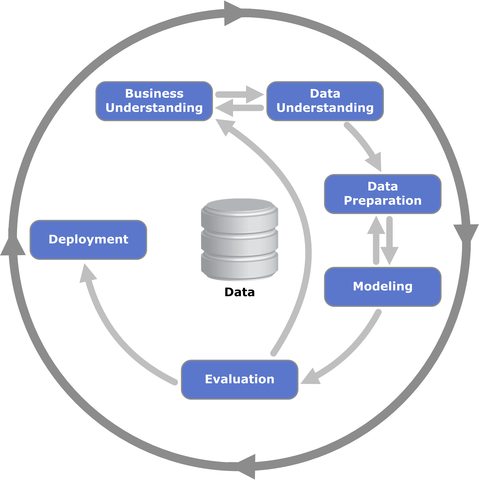

;

Extracted from https://www.datasciencecentral.com/profiles/blogs/crisp-dm-a-standard-methodology-to-ensure-a-good-outcome

# Create Dataset

```r
docs <- c("This food is good", "This burger is good", "fish burger is great", "chicken burger is good", "this pancake is great", "this burger is good", "this burger is great");

c <- c(1, 0, 0, 1, 1, 0, 1);

corpus <- VCorpus(VectorSource(docs));
```

# Data Understanding

We can use the following codes to understand our text data. We created the Document Term Matrix and the Term Document Matrix using the tm package. We have also plotted the words or term with the number of occurrence or term frequency:

```r
dtm <- DocumentTermMatrix(corpus);
inspect(dtm);
```

```
## <<DocumentTermMatrix (documents: 7, terms: 8)>>
## Non-/sparse entries: 21/35
## Sparsity           : 62%
## Maximal term length: 7
## Weighting          : term frequency (tf)
## Sample             :
##     Terms
## Docs burger chicken fish food good great pancake this
##    1      0       0    0    1    1     0       0    1
##    2      1       0    0    0    1     0       0    1
##    3      1       0    1    0    0     1       0    0
##    4      1       1    0    0    1     0       0    0
##    5      0       0    0    0    0     1       1    1
##    6      1       0    0    0    1     0       0    1
##    7      1       0    0    0    0     1       0    1
```

```r
tdm <- TermDocumentMatrix(corpus);
inspect(tdm);
```

```
## <<TermDocumentMatrix (terms: 8, documents: 7)>>
## Non-/sparse entries: 21/35
## Sparsity           : 62%
## Maximal term length: 7
## Weighting          : term frequency (tf)
## Sample             :
##          Docs
## Terms     1 2 3 4 5 6 7
##   burger  0 1 1 1 0 1 1
##   chicken 0 0 0 1 0 0 0
##   fish    0 0 1 0 0 0 0
##   food    1 0 0 0 0 0 0
##   good    1 1 0 1 0 1 0
##   great   0 0 1 0 1 0 1
##   pancake 0 0 0 0 1 0 0
##   this    1 1 0 0 1 1 1
```

```r
freq <- rowSums(as.matrix(tdm));
freq;
```

```
##  burger chicken    fish    food    good   great pancake    this
##       5       1       1       1       4       3       1       5
```

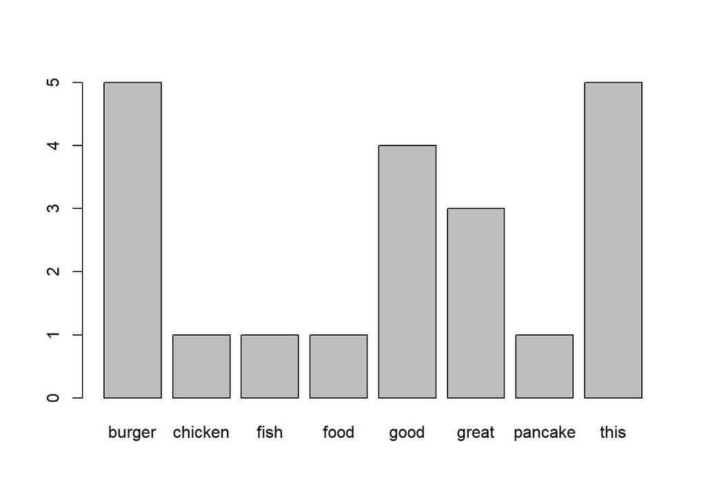

```r
barplot(freq);
```

We can create Word Cloud.

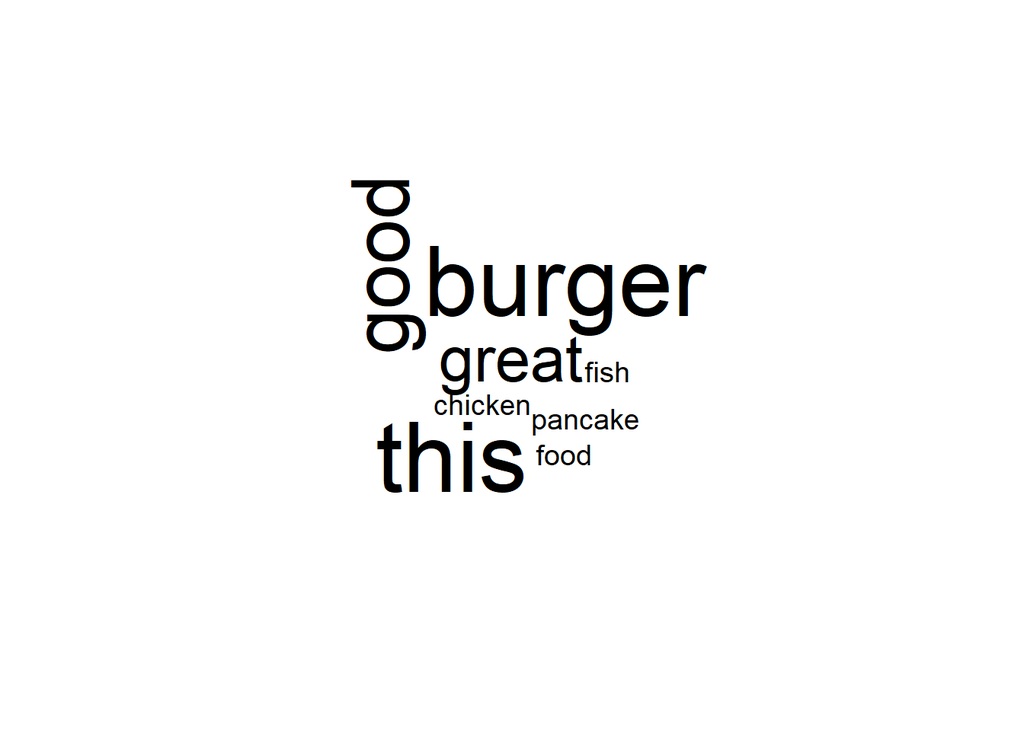

```r
wordcloud(corpus, min.freq = 1, random.color = FALSE);
```

Saying about Part of Speech Tagging, before I forget, You can use DSTK to create Text Analysis. The following links 6 people said staffs are friendly. nn is noun, jj is adjectives.

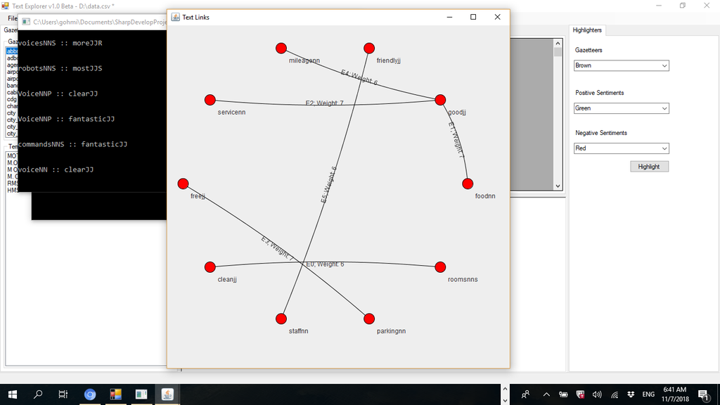

# Data Preparation

We have removed numbers, stem the words, remove punctuations, and remove stopwords using tm_map.

We split the data into training sets and testing sets sample.split.

Stopwords are commonly used words. Remove stopwords point to remove of commonly used words. Stop words is as follows:

```r
stopwords("en");
```

```
##   [1] "i"          "me"         "my"         "myself"     "we"
##   [6] "our"        "ours"       "ourselves"  "you"        "your"
##  [11] "yours"      "yourself"   "yourselves" "he"         "him"
##  [16] "his"        "himself"    "she"        "her"        "hers"
##  [21] "herself"    "it"         "its"        "itself"     "they"
##  [26] "them"       "their"      "theirs"     "themselves" "what"
##  [31] "which"      "who"        "whom"       "this"       "that"
##  [36] "these"      "those"      "am"         "is"         "are"
##  [41] "was"        "were"       "be"         "been"       "being"
##  [46] "have"       "has"        "had"        "having"     "do"
##  [51] "does"       "did"        "doing"      "would"      "should"
##  [56] "could"      "ought"      "i'm"        "you're"     "he's"
##  [61] "she's"      "it's"       "we're"      "they're"    "i've"
##  [66] "you've"     "we've"      "they've"    "i'd"        "you'd"
##  [71] "he'd"       "she'd"      "we'd"       "they'd"     "i'll"
```

[output cut: 20 more lines]

Stemming is the process of reducing a word to its word stem. Documents are going to use different forms of words, like organize, organizes, and organizing. Stemming is going to make it to organize.

We remove stopwords, remove numbers, remove punctuation, to lowercase and stemming.

```r
corpus <- tm_map(corpus, content_transformer(tolower));
corpus <- tm_map(corpus, removeNumbers);
corpus <- tm_map(corpus, removePunctuation);
corpus <- tm_map(corpus, removeWords, stopwords());
corpus <- tm_map(corpus, stemDocument);

dtm <- DocumentTermMatrix(corpus);
dtm <- removeSparseTerms(dtm, 0.9);

data <- as.data.frame(as.matrix(dtm));
data$cls <- c;
```

We split data to training set and testing set.

```r
split <- sample.split(data$cls, SplitRatio = 0.75);
training_set <- subset(data, split == TRUE);
test_set <- subset(data, split == FALSE);

training_set;
```

```
##   burger chicken fish food good great pancak cls
## 1      0       0    0    1    1     0      0   1
## 2      1       0    0    0    1     0      0   0
## 3      1       0    1    0    0     1      0   0
## 4      1       1    0    0    1     0      0   1
## 5      0       0    0    0    0     1      1   1
```

```r
test_set;
```

```
##   burger chicken fish food good great pancak cls
## 6      1       0    0    0    1     0      0   0
## 7      1       0    0    0    0     1      0   1
```

```r
training_setWithCls <- training_set;
test_setWithCls <- test_set;
```

# Modeling

We create the model on our text data. We classify the new data using the model. We can accomplish these using the following codes:

```r
training_set$cls <- NULL;
test_set$cls <- NULL;

training_set;
```

```
##   burger chicken fish food good great pancak
## 1      0       0    0    1    1     0      0
## 2      1       0    0    0    1     0      0
## 3      1       0    1    0    0     1      0
## 4      1       1    0    0    1     0      0
## 5      0       0    0    0    0     1      1
```

```r
test_set;
```

```
##   burger chicken fish food good great pancak
## 6      1       0    0    0    1     0      0
## 7      1       0    0    0    0     1      0
```

```r
model <- randomForest(x = training_set, y = training_setWithCls$cls);
model;
```

```
##
## Call:
##  randomForest(x = training_set, y = training_setWithCls$cls)
##                Type of random forest: regression
##                      Number of trees: 500
## No. of variables tried at each split: 2
##
##           Mean of squared residuals: 0.4453729
##                     % Var explained: -85.57
```

```r
y_pred <- predict(model, newdata = test_set);
y_pred;
```

```
##      6      7
## 0.5603 0.5098
```

# Evaluation

We can use the following code to get Confusion Matrix and evaluate our model:

```r
table(y_pred, test_setWithCls$cls );
```

```
##
## y_pred   0 1
##   0.5098 0 1
##   0.5603 1 0
```